# Data Analysis Religiosity’s Part on Social Adaptation

Alejandra Neely-Prado, Michiel van Elk, Gorka Navarrete, Fernanda Hola, David Huepe

12-09-2021

This document contains the pre-registered analysis plan, and also an exploratory analysis.

# Pre-registered analysis plan

## Statistical Analysis

### Reliability

To start the analysis, we will get Cronbach’s alpha to check each questionnaires reliability. In general all questionnaires show good levels of reliability.

#### Religiosity

|  | raw_alpha | std.alpha | G6(smc) | average_r | S/N | ase | mean | sd | median_r |
| --- | --- | --- | --- | --- | --- | --- | --- | --- | --- |
|  | 0.9575068 | 0.9571503 | 0.9574142 | 0.6907605 | 22.33739 | 0.0028142 | 2.136214 | 0.8777697 | 0.701521 |

#### Social Adaptation

|  | raw_alpha | std.alpha | G6(smc) | average_r | S/N | ase | mean | sd | median_r |
| --- | --- | --- | --- | --- | --- | --- | --- | --- | --- |
|  | 0.7536265 | 0.7681555 | 0.7992061 | 0.1421183 | 3.313237 | 0.0161323 | 2.085905 | 0.3279142 | 0.1277525 |

#### Self-Esteem

|  | raw_alpha | std.alpha | G6(smc) | average_r | S/N | ase | mean | sd | median_r |
| --- | --- | --- | --- | --- | --- | --- | --- | --- | --- |
|  | 0.8493572 | 0.854512 | 0.8736695 | 0.3700161 | 5.87342 | 0.0101385 | 3.159671 | 0.5469872 | 0.3610125 |

## Results

### Descriptives

272 females (55.97%) and 214 males (44.03%) enrolled in this study, with an average age of 31.64 and 31.36, respectively.

The following table show the descriptive statistics for each independent and dependent variable.

```
##
##  Descriptive statistics by group
## group: CN
##                   vars   n  mean   sd median trimmed   mad min max range  skew
## Religiosity          1 243 20.64 8.50     20   19.92 10.38  10  40    30  0.46
## Social-Adaptation    2 243 43.98 6.16     45   44.23  5.93  18  58    40 -0.53
## Self-Esteem          3 243 31.23 5.23     32   31.45  5.93  17  40    23 -0.35
##                   kurtosis   se
## Religiosity          -0.67 0.55
## Social-Adaptation     0.76 0.40
## Self-Esteem          -0.54 0.34
## ------------------------------------------------------------
## group: EX
##                   vars   n  mean   sd median trimmed   mad min max range  skew
## Religiosity          1 243 22.08 9.01     22   21.73 11.86  10  40    30  0.05
## Social-Adaptation    2 243 40.52 6.17     41   40.79  5.93  18  53    35 -0.46
## Self-Esteem          3 243 31.96 5.69     33   32.45  5.93  12  40    28 -0.84
##                   kurtosis   se
## Religiosity          -1.15 0.58
## Social-Adaptation     0.21 0.40
## Self-Esteem           0.52 0.36
```

### Correlations

Religiosity has a very small correlation with Social-Adaptation (r = 0.0692726, p = 0.2544967).  
Religiosity has a very small correlation with Self-Esteem (r = 0.0690528, p = 0.2544967).  
Social-Adaptation has a moderate correlation with Self-Esteem (r = 0.4543737, p = 1.1800063^{-25}).

**[This is not autogenerated]**: Independent variables are not correlated. Regarding the dependent variable (Social-Adaptation), it has a medium correlation with self-esteem (r = .45, p < .01), and non correlation with religiosity.

[output not shown]

```
##
##
## Table 2
##
## Means, standard deviations, and correlations with confidence intervals
##
##
##   Variable             M     SD   1           2
##   1. Religiosity       21.36 8.78
##
##   2. Social-Adaptation 42.25 6.40 .07
##                                   [-.02, .16]
##
##   3. Self-Esteem       31.60 5.47 .07         .45**
##                                   [-.02, .16] [.38, .52]
##
##
## Note. M and SD are used to represent mean and standard deviation, respectively.
## Values in square brackets indicate the 95% confidence interval.
## The confidence interval is a plausible range of population correlations
## that could have caused the sample correlation (Cumming, 2014).
##  * indicates p < .05. ** indicates p < .01.
##
```

```
## # Correlation Matrix (pearson-method)
##
## Parameter1        |        Parameter2 |    r |        95% CI | t(484) |         p
## ---------------------------------------------------------------------------------
## Religiosity       | Social-Adaptation | 0.07 | [-0.02, 0.16] |   1.53 | 0.254
## Religiosity       |       Self-Esteem | 0.07 | [-0.02, 0.16] |   1.52 | 0.254
## Social-Adaptation |       Self-Esteem | 0.45 | [ 0.38, 0.52] |  11.22 | < .001***
##
## p-value adjustment method: Holm (1979)
## Observations: 486
```

### Regressions

As we can see from the outputs below, we can reject the hypothesis that Religiosity predicts Social Adaptation.

```
##
## Call:
## lm(formula = `Social-Adaptation` ~ Religiosity, data = matched)
##
## Residuals:
##      Min       1Q   Median       3Q      Max
## -25.1921  -4.3085   0.6663   4.4012  16.1712
##
## Coefficients:
##             Estimate Std. Error t value Pr(>|t|)
## (Intercept) 41.17240    0.76323  53.945   <2e-16 ***
## Religiosity  0.05049    0.03305   1.528    0.127
## ---
## Signif. codes:  0 '***' 0.001 '**' 0.01 '*' 0.05 '.' 0.1 ' ' 1
##
## Residual standard error: 6.389 on 484 degrees of freedom
## Multiple R-squared:  0.004799,   Adjusted R-squared:  0.002742
## F-statistic: 2.334 on 1 and 484 DF,  p-value: 0.1272
```

We can also reject the hypothesis that Religiosity predicts Self-Esteem.

```
##
## Call:
## lm(formula = `Self-Esteem` ~ Religiosity, data = matched)
##
## Residuals:
##      Min       1Q   Median       3Q      Max
## -19.8823  -3.7963   0.6874   4.4619   8.8922
##
## Coefficients:
##             Estimate Std. Error t value Pr(>|t|)
## (Intercept) 30.67748    0.65252  47.014   <2e-16 ***
## Religiosity  0.04303    0.02826   1.523    0.128
## ---
## Signif. codes:  0 '***' 0.001 '**' 0.01 '*' 0.05 '.' 0.1 ' ' 1
##
## Residual standard error: 5.462 on 484 degrees of freedom
## Multiple R-squared:  0.004768,   Adjusted R-squared:  0.002712
## F-statistic: 2.319 on 1 and 484 DF,  p-value: 0.1285
```

Also, group has no moderation nor mediation effect on religiosity for predicting levels of self-esteem.

```
##
## Call:
## lm(formula = `Self-Esteem` ~ Religiosity + group + xz, data = matched2)
##
## Residuals:
##      Min       1Q   Median       3Q      Max
## -20.0187  -3.7201   0.5396   4.5299   9.5575
##
## Coefficients:
##             Estimate Std. Error t value Pr(>|t|)
## (Intercept) 29.70200    0.92071  32.260   <2e-16 ***
## Religiosity  0.07405    0.04126   1.795   0.0733 .
## group        2.05310    1.30760   1.570   0.1170
## xz          -0.06463    0.05673  -1.139   0.2552
## ---
## Signif. codes:  0 '***' 0.001 '**' 0.01 '*' 0.05 '.' 0.1 ' ' 1
##
## Residual standard error: 5.456 on 482 degrees of freedom
## Multiple R-squared:  0.01122,    Adjusted R-squared:  0.005067
## F-statistic: 1.823 on 3 and 482 DF,  p-value: 0.142
```

And group has no moderation nor mediation effect on religiosity for predicting levels of social adaptation.

```
##
## Call:
## lm(formula = `Social-Adaptation` ~ Religiosity + group + xz,
##     data = matched2)
##
## Residuals:
##     Min      1Q  Median      3Q     Max
## -26.012  -3.685   0.434   4.160  14.621
##
## Coefficients:
##             Estimate Std. Error t value Pr(>|t|)
## (Intercept) 42.34944    1.03760  40.815   <2e-16 ***
## Religiosity  0.07916    0.04649   1.703   0.0893 .
## group       -3.07828    1.47360  -2.089   0.0372 *
## xz          -0.02268    0.06394  -0.355   0.7230
## ---
## Signif. codes:  0 '***' 0.001 '**' 0.01 '*' 0.05 '.' 0.1 ' ' 1
##
## Residual standard error: 6.149 on 482 degrees of freedom
## Multiple R-squared:  0.08215,    Adjusted R-squared:  0.07644
## F-statistic: 14.38 on 3 and 482 DF,  p-value: 5.481e-09
```

As we can see, from the previous outputs, religiosity has no significant effect either on the independent variable nor on the mediator. Thus, we can say that religiosity does not predict social adaptation through self-esteem in any case.

# Exploratory Analysis

## Network correlation plot between items

The following network plot aims at discovering items between questionnaires that could be correlated between eachother. As we can see some items of the Social Adaptation Self-Evaluation Scale (SASS) do correlate with some items of Rosenberg’s Self-Esteem Scale (EAR), while religiosity items do not correlate at all with either.

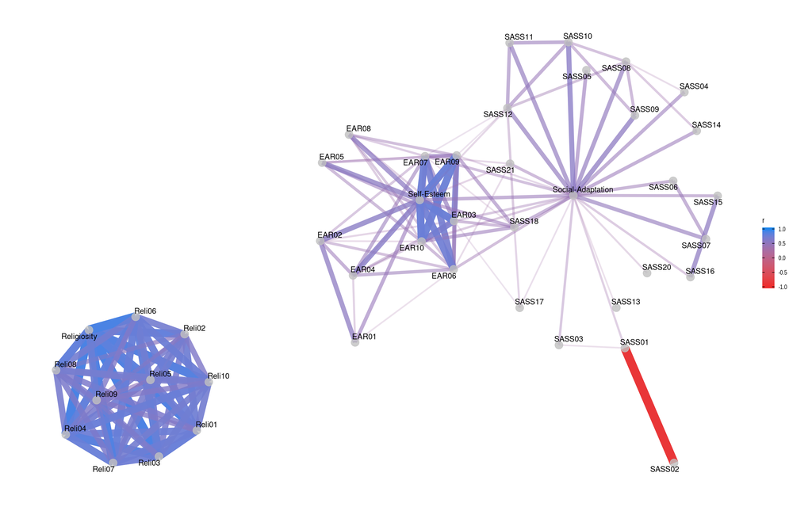

## ANOVA analysis to evaluate group differences in Self-Esteem, Religiosity and Social Adaptation

| **Characteristic** | **CN**, N = 243<sup>1</sup> | **EX**, N = 243<sup>1</sup> | **Difference**<sup>2</sup> | **95% CI**<sup>2,3</sup> | **p-value**<sup>2</sup> |
| --- | --- | --- | --- | --- | --- |
| Self-Esteem | 31.2 (5.2) | 32.0 (5.7) | -0.73 | -1.7, 0.24 | 0.14 |
| Religiosity | 21 (9) | 22 (9) | -1.4 | -3.0, 0.12 | 0.070 |
| Social-Adaptation | 44 (6) | 41 (6) | 3.5 | 2.4, 4.6 | <0.001 |

<sup>*1*</sup> Mean (SD) <sup>*2*</sup> One-way ANOVA <sup>*3*</sup> CI = Confidence Interval

There is no statistical difference between self-esteem scores in the vulnerable group vs the non-vulnerable group

```
##              Df Sum Sq Mean Sq F value Pr(>F)
## group         1     65   65.19   2.184   0.14
## Residuals   484  14446   29.85
```

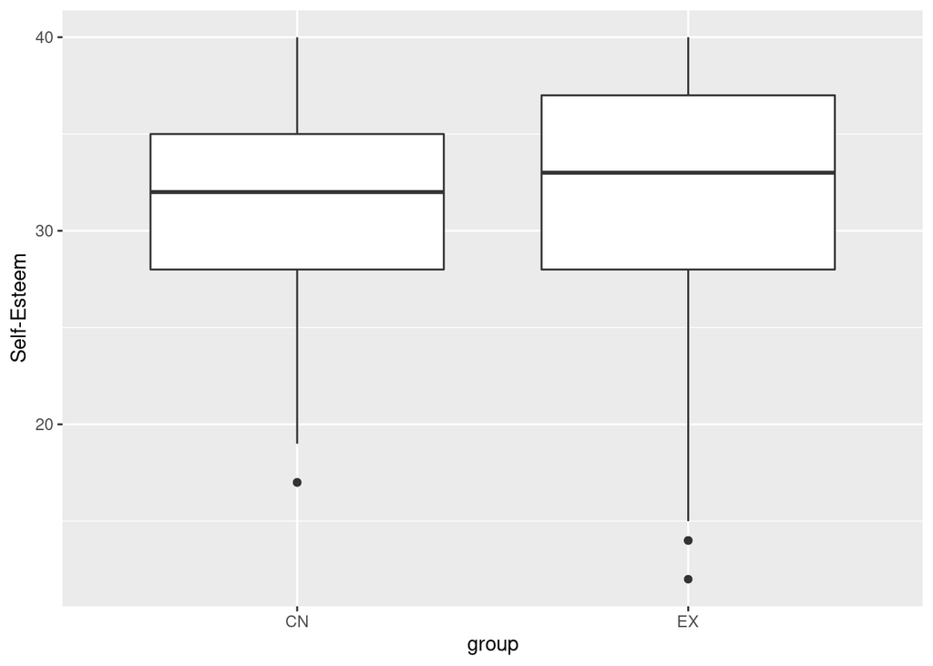

There is no statistical difference between religiosity scores in the vulnerable group vs the non-vulnerable group

```
##              Df Sum Sq Mean Sq F value Pr(>F)
## group         1    252  252.06   3.287 0.0705 .
## Residuals   484  37116   76.69
## ---
## Signif. codes:  0 '***' 0.001 '**' 0.01 '*' 0.05 '.' 0.1 ' ' 1
```

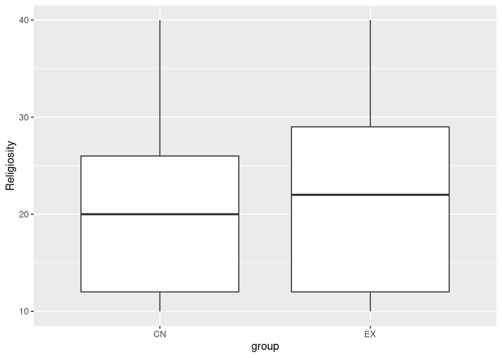

Social adaptation scores are higher in the non-vulnerable group than in the non-vulnerable group

```
##              Df Sum Sq Mean Sq F value   Pr(>F)
## group         1   1459    1459   38.38 1.24e-09 ***
## Residuals   484  18395      38
## ---
## Signif. codes:  0 '***' 0.001 '**' 0.01 '*' 0.05 '.' 0.1 ' ' 1
```

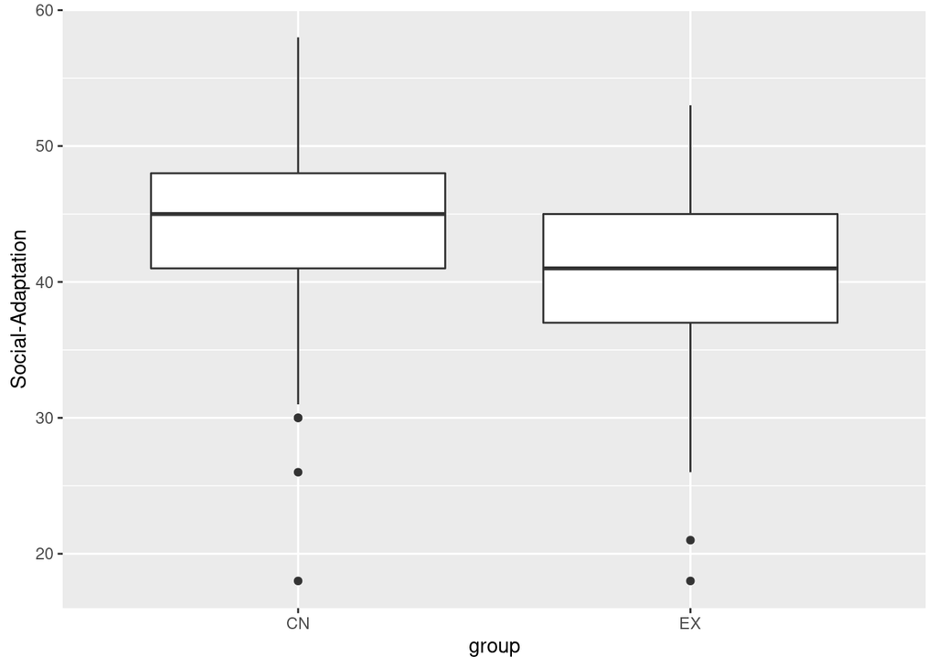

## Regression analysis between Religiosity, Self-Esteem and Perceived Stress

Since some studies that show a significant relationship between religiosity to coping and stress management, we added a perceived stress scale, and tested if religiosity predicts lower perceived stress through self-esteem.

There is no effect of religiosity over perceived stress.

```
##
## Call:
## lm(formula = Estres_Percibido ~ Religiosity, data = matched2)
##
## Residuals:
##      Min       1Q   Median       3Q      Max
## -19.3205  -5.0482  -0.2731   4.7111  21.3988
##
## Coefficients:
##             Estimate Std. Error t value Pr(>|t|)
## (Intercept) 26.00821    0.86962  29.908   <2e-16 ***
## Religiosity -0.06877    0.03766  -1.826   0.0684 .
## ---
## Signif. codes:  0 '***' 0.001 '**' 0.01 '*' 0.05 '.' 0.1 ' ' 1
##
## Residual standard error: 7.28 on 484 degrees of freedom
## Multiple R-squared:  0.006843,   Adjusted R-squared:  0.004791
## F-statistic: 3.335 on 1 and 484 DF,  p-value: 0.06844
```

If we consider the experimental group, there is also no moderation nor mediation effect.

```
##
## Call:
## lm(formula = Estres_Percibido ~ Religiosity + group + xz, data = matched2)
##
## Residuals:
##      Min       1Q   Median       3Q      Max
## -18.8201  -4.8982  -0.4643   4.7892  22.9475
##
## Coefficients:
##             Estimate Std. Error t value Pr(>|t|)
## (Intercept) 25.92707    1.21960  21.259   <2e-16 ***
## Religiosity -0.11070    0.05465  -2.026   0.0433 *
## group        0.57546    1.73207   0.332   0.7399
## xz           0.06241    0.07515   0.831   0.4067
## ---
## Signif. codes:  0 '***' 0.001 '**' 0.01 '*' 0.05 '.' 0.1 ' ' 1
##
## Residual standard error: 7.227 on 482 degrees of freedom
## Multiple R-squared:  0.02522,    Adjusted R-squared:  0.01915
## F-statistic: 4.156 on 3 and 482 DF,  p-value: 0.006356
```

However, we can see that self-esteem does predict perceived stress

```
##
## Call:
## lm(formula = Estres_Percibido ~ `Self-Esteem`, data = matched2)
##
## Residuals:
##      Min       1Q   Median       3Q      Max
## -19.4475  -3.9393  -0.2753   4.2079  19.2462
##
## Coefficients:
##               Estimate Std. Error t value Pr(>|t|)
## (Intercept)   48.57657    1.59735   30.41   <2e-16 ***
## `Self-Esteem` -0.76076    0.04981  -15.27   <2e-16 ***
## ---
## Signif. codes:  0 '***' 0.001 '**' 0.01 '*' 0.05 '.' 0.1 ' ' 1
##
## Residual standard error: 6.001 on 484 degrees of freedom
## Multiple R-squared:  0.3252, Adjusted R-squared:  0.3238
## F-statistic: 233.2 on 1 and 484 DF,  p-value: < 2.2e-16
```

From the output below we can say that self-esteem also predict social adaptation.

```
##
## Call:
## lm(formula = `Social-Adaptation` ~ `Self-Esteem`, data = matched)
##
## Residuals:
##      Min       1Q   Median       3Q      Max
## -16.9968  -3.8552   0.4087   4.0504  16.1641
##
## Coefficients:
##               Estimate Std. Error t value Pr(>|t|)
## (Intercept)   25.45819    1.51870   16.76   <2e-16 ***
## `Self-Esteem`  0.53147    0.04736   11.22   <2e-16 ***
## ---
## Signif. codes:  0 '***' 0.001 '**' 0.01 '*' 0.05 '.' 0.1 ' ' 1
##
## Residual standard error: 5.705 on 484 degrees of freedom
## Multiple R-squared:  0.2065, Adjusted R-squared:  0.2048
## F-statistic: 125.9 on 1 and 484 DF,  p-value: < 2.2e-16
```

```
##
## Call:
## lm(formula = `Social-Adaptation` ~ `Self-Esteem` + group + xy,
##     data = matched2)
##
## Residuals:
##      Min       1Q   Median       3Q      Max
## -16.0959  -3.2894   0.1649   3.8162  16.2124
##
## Coefficients:
##               Estimate Std. Error t value Pr(>|t|)
## (Intercept)   22.28394    2.07610  10.734  < 2e-16 ***
## `Self-Esteem`  0.69482    0.06557  10.597  < 2e-16 ***
## group          4.25537    2.85228   1.492  0.13637
## xy            -0.25747    0.08904  -2.891  0.00401 **
## ---
## Signif. codes:  0 '***' 0.001 '**' 0.01 '*' 0.05 '.' 0.1 ' ' 1
##
## Residual standard error: 5.332 on 482 degrees of freedom
## Multiple R-squared:  0.3098, Adjusted R-squared:  0.3055
## F-statistic:  72.1 on 3 and 482 DF,  p-value: < 2.2e-16
```

And that religiosity does predict perceived stress when we take self-esteem into account, finding both a moderation and a mediation effect.

```
##
## Call:
## lm(formula = Estres_Percibido ~ Religiosity + `Self-Esteem` +
##     xw, data = matched2)
##
## Residuals:
##      Min       1Q   Median       3Q      Max
## -15.7762  -3.9739  -0.3538   4.0621  20.4370
##
## Coefficients:
##                Estimate Std. Error t value Pr(>|t|)
## (Intercept)   64.800420   3.868911  16.749  < 2e-16 ***
## Religiosity   -0.782944   0.170316  -4.597 5.48e-06 ***
## `Self-Esteem` -1.247843   0.120588 -10.348  < 2e-16 ***
## xw             0.023429   0.005257   4.457 1.04e-05 ***
## ---
## Signif. codes:  0 '***' 0.001 '**' 0.01 '*' 0.05 '.' 0.1 ' ' 1
##
## Residual standard error: 5.885 on 482 degrees of freedom
## Multiple R-squared:  0.3537, Adjusted R-squared:  0.3497
## F-statistic: 87.93 on 3 and 482 DF,  p-value: < 2.2e-16
```

## ANOVA analysis between other Religiosity measures and Social Adaptation in non-vulnerable contexts

Since some studies that show a significant relationship between religiosity and variables related to coping and stress management use religiosity measures of religious practice and/or affiliation, we added these questions in the questionnaire that was applied to the non-vulnerable group. We now check if these variables, religious service attendance and affiliation are related to social adaptation or to self-esteem.

The following ANOVA analysis show that there is no difference on social adaptation nor in social adaptation levels depending on different religious service attendance levels nor type of affiliation among people who do not live in vulnerable contexts. This contradicts literature that have found that religiosity has a general positive impact on mental health variables.

#### Religious Service Attendance and Self-Esteem

```
##                  Df Sum Sq Mean Sq F value Pr(>F)
## `RS Attendance`   6    235   39.19    1.45  0.196
## Residuals       232   6270   27.02
```

#### Religious Service Attendance and Social Adaptation

```
##                  Df Sum Sq Mean Sq F value Pr(>F)
## `RS Attendance`   6    290   48.40   1.289  0.263
## Residuals       232   8714   37.56
```

#### Affiliation and Self-Esteem

```
##              Df Sum Sq Mean Sq F value Pr(>F)
## Affiliation   4     88   22.11   0.806  0.522
## Residuals   234   6416   27.42
```

#### Affiliation and Social Adaptation

```
##              Df Sum Sq Mean Sq F value Pr(>F)
## Affiliation   4    119   29.83   0.786  0.535
## Residuals   234   8885   37.97
```